# Correlation in R

PS50008A Week 15 Lab Activity

Author

Gordon Wright

Published

11 February 2026

## Overview

**ImportantFocus for Today**

This lab explores **correlation** - measuring the relationship between two continuous variables:

- Creating effective scatterplots
- Calculating Pearson’s r in R
- Interpreting correlation coefficients
- Applying correlation to your own data

**TipInteractive Tool: Correlation Playground**

Explore correlation interactively with the **Correlation Playground** app:

[🎮 Launch Correlation Playground](https://littlemonkeylab.github.io/GS_shinyapps/apps/correlation-playground/)

This tool lets you:

- Adjust correlation strength and see how scatterplots change
- Explore the relationship between r values and visual patterns
- Build intuition for interpreting correlations

## Activity 1: Creating Scatterplots (15 min)

### Visualising Relationships

Before calculating correlations, we should always visualise the relationship with a scatterplot.

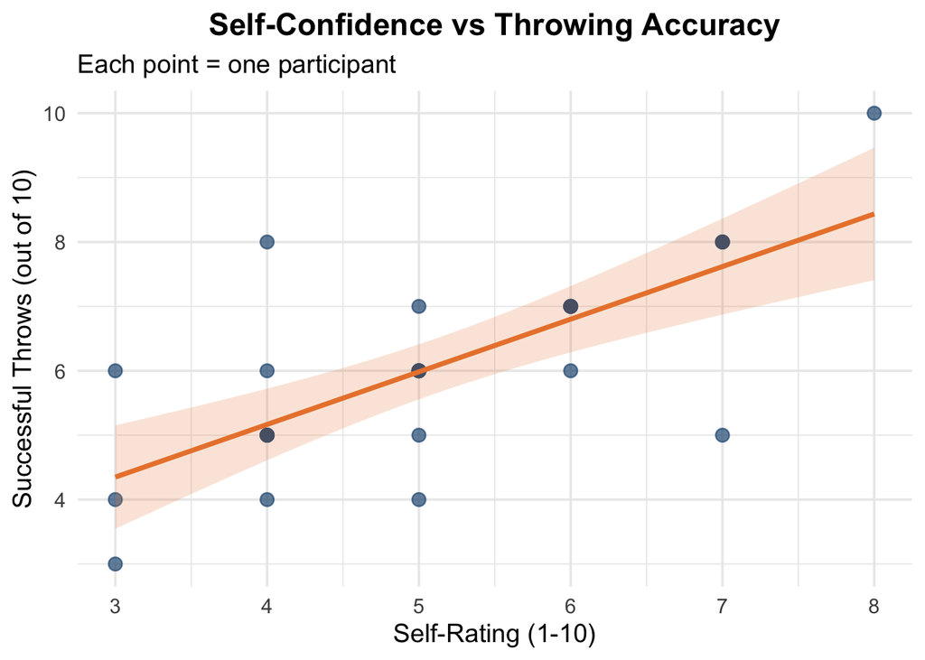

### Understanding Scatterplots

**1. In a scatterplot, each point represents:**

**2. The x-axis typically shows:**

**3. What does the line of best fit show?**

### Reading Scatterplot Patterns

**4. If points cluster tightly around an upward-sloping line, this suggests:**

**5. If points are scattered randomly with no clear pattern, this suggests:**

**6. If points cluster around a downward-sloping line, this suggests:**

True or False: We should always create a scatterplot before calculating a correlation.

True or False: Scatterplots can reveal non-linear relationships that correlation coefficients might miss.

## Activity 2: Calculating Correlations (15 min)

### Pearson’s r

The Pearson correlation coefficient (r) measures the strength and direction of a **linear** relationship between two continuous variables.

### Properties of r

**1. Pearson’s r ranges from:**

**2. An r value of 0 means:**

**3. An r value of -0.8 indicates:**

### R Syntax

In R, we calculate correlation using `cor()` or `cor.test()`:

```r
# Simple correlation
cor(variable1, variable2)

# Correlation with p-value and CI
cor.test(variable1, variable2)
```

**4. What is the key difference between `cor()` and `cor.test()`?**

### Reading R Output

Here’s example output from `cor.test()`:

```
    Pearson's product-moment correlation

data:  self_rating and accuracy
t = 3.45, df = 28, p-value = 0.002
alternative hypothesis: true correlation is not equal to 0
95 percent confidence interval:
 0.24  0.75
sample estimates:
      cor
0.55
```

**5. What is the correlation coefficient (r)?**

**6. Is this correlation statistically significant at alpha = 0.05?**

**7. The 95% CI is [0.24, 0.75]. What does this tell us?**

## Activity 2b: Interpreting Scatterplots (10 min)

Look at each scatterplot below and estimate the correlation.

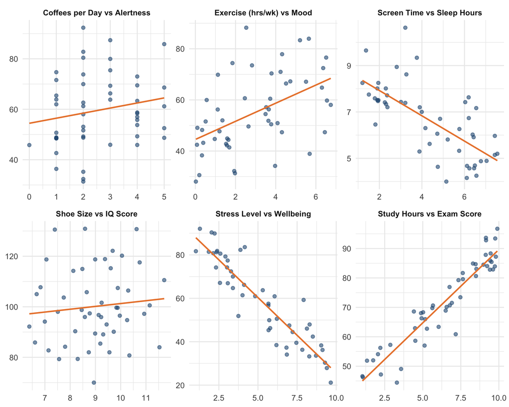

### Match the Correlations

The six scatterplots above have these r values (in random order): **-0.75, -0.48, 0.03, 0.28, 0.47, 0.85**

**1. Study Hours vs Exam Score:**

**2. Screen Time vs Sleep Hours:**

**3. Shoe Size vs IQ Score:**

**4. Stress Level vs Wellbeing:**

**5. Coffees per Day vs Alertness:**

**6. Exercise vs Mood:**

**TipInterpretation Tips**

- **Strong correlations** (|r| > 0.5): Points cluster tightly around the line
- **Moderate correlations** (|r| = 0.3-0.5): Clear trend but more scatter
- **Weak correlations** (|r| < 0.3): Trend barely visible, lots of scatter
- **Near-zero correlations**: No discernible pattern at all
- **Negative correlations**: Line slopes downward (one goes up, other goes down)

## Activity 3: Interpreting r Values (15 min)

### Cohen’s Guidelines

Jacob Cohen provided rough guidelines for interpreting correlation strength:

|  | r |
| --- | --- |
| 0.10 - 0.29 | Small/weak |
| 0.30 - 0.49 | Medium/moderate |
| 0.50 - 1.00 | Large/strong |

### Practice Interpretation

**1. r = 0.25 would be considered:**

**2. r = -0.65 would be considered:**

**3. r = 0.42 would be considered:**

### Coefficient of Determination (r-squared)

Squaring r tells us the proportion of variance explained.

**4. If r = 0.50, then r-squared (r^2) equals:**

**5. r^2 = 0.25 means:**

**6. If r = 0.70, what percentage of variance is explained?**

### Critical Thinking

**7. A statistically significant correlation of r = 0.15 suggests:**

True or False: A significant p-value tells us the correlation is strong.

True or False: Correlation does not imply causation.

True or False: A negative correlation is weaker than a positive correlation of the same magnitude.

## Activity 4: Correlation in YOUR Data (10 min)

### Applying to DataLab

Let’s think about correlational questions we could ask with the DataLab data.

### Question 1: Self-Rating and Performance

In the Frontal Lob task, participants rated their throwing ability before throwing.

**If high self-ratings are associated with better performance, what type of correlation would we expect?**

**Is there an IV and DV in this analysis?**

### Question 2: Sleep and Memory

Imagine we correlate hours of sleep the night before with memory test performance.

**What would a negative correlation (r = -0.30) mean?**

**Could we conclude that lack of sleep causes poor memory?**

### Question 3: Third Variables

Sleep quality might be related to both coffee consumption AND memory performance.

**This illustrates:**

**If coffee consumption is related to both variables, it could:**

## Remaining Time: Research Plan Work (20+ min)

**WarningResearch Plan Due Friday 27 February**

Use the remaining lab time to work on your **Research Plan submission**. Your instructor is available to help!

### What to Work On

If you haven’t started:

1. Choose your research question from the approved topics
2. Identify your IV and DV
3. Decide on your design (between/within-subjects)

If you’ve already started:

1. Refine your hypotheses (H1 and H0)
2. Check your operationalisation is clear and measurable
3. Review the marking criteria on Learn

### Get Feedback Now

**TipAsk Questions Today!**

This is your last lab before Reading Week. Instructors can give feedback on:

- Whether your hypothesis is testable
- If your IV/DV are properly operationalised
- Whether your design makes sense for your question

## Summary

**ImportantKey Takeaways**

**Scatterplots:**

- Always visualise before calculating
- Each point = one participant
- Look for patterns, linearity, and outliers

**Pearson’s r:**

- Ranges from -1 to +1
- Sign indicates direction (positive/negative)
- Magnitude indicates strength

**Interpretation:**

- Small: |r| = 0.10 - 0.29
- Medium: |r| = 0.30 - 0.49
- Large: |r| = 0.50+
- r^2 = proportion of variance explained

**Cautions:**

- Correlation does NOT equal causation
- Watch for third variables
- Statistical significance does not equal practical importance

## Next Steps

1. Complete the Week 15 Self-Assessment
2. Review the Lecture Reading
3. Prepare for Week 16: Project Groups - Literature Review